# Analysis of Povety in America and the Implications of Race

Finally we will fit the regression model of the standarized data of Percent Below Poverty and see its relationhship to race and how that interacts with the perecntage of female HoH Below Poverty.

```python
# Get mean and standard deviations of percent below poverty
mean = finalDF["Percent Below Poverty"].mean()
std = finalDF["Percent Below Poverty"].std()

# Obtain the standardized values for the percent below poverty for each datapoint
finalDF["Percent_Below_Poverty_std"] = (finalDF["Percent Below Poverty"] - mean) / std

# Sample 95% of the data for 95% confidence interval
final_train = finalDF.sample(frac=0.95)
final_test = finalDF.drop(final_train.index)

# Print fitted linear regression of relation between percent below poverty standardized and race and percent female head
# of house hold
newRes = smf.ols(formula="Percent_Below_Poverty_std ~ Race + Q(\"Percent Female HoH Below Poverty\")", data=final_train).fit()
print(newRes.summary())
```

```
                                OLS Regression Results
=====================================================================================
Dep. Variable:     Percent_Below_Poverty_std   R-squared:                       0.950
Model:                                   OLS   Adj. R-squared:                  0.949
Method:                        Least Squares   F-statistic:                     847.5
Date:                       Fri, 12 May 2023   Prob (F-statistic):          1.96e-142
Time:                               17:45:04   Log-Likelihood:                 17.303
No. Observations:                        228   AIC:                            -22.61
Df Residuals:                            222   BIC:                            -2.030
Df Model:                                  5
Covariance Type:                   nonrobust
=========================================================================================================
                                            coef    std err          t      P>|t|      [0.025      0.975]
---------------------------------------------------------------------------------------------------------
Intercept                                -1.3203      0.100    -13.199      0.000      -1.517      -1.123
Race[T.Asian/Pacific Islander]           -0.7019      0.072     -9.806      0.000      -0.843      -0.561
Race[T.Black]                             0.1415      0.051      2.783      0.006       0.041       0.242
Race[T.Hispanic]                         -0.3196      0.051     -6.285      0.000      -0.420      -0.219
Race[T.White]                            -1.1511      0.059    -19.595      0.000      -1.267      -1.035
Q("Percent Female HoH Below Poverty")     0.0468      0.002     21.940      0.000       0.043       0.051
==============================================================================
Omnibus:                       28.142   Durbin-Watson:                   1.787
Prob(Omnibus):                  0.000   Jarque-Bera (JB):               55.368
Skew:                          -0.627   Prob(JB):                     9.48e-13
Kurtosis:                       5.063   Cond. No.                         338.
==============================================================================

Notes:
[1] Standard Errors assume that the covariance matrix of the errors is correctly specified.
```

**Machine Learning**

Compare machine learning model results to previous model results

First we will run our data through a gradient descent algorithm.

Gradient descent in machine learning is an optimization algorithm whic uses training data to learn over time and devlop things like neural networks. More information ont his powerful AI tool can be found here: [IBM Source](https://www.ibm.com/topics/gradient-descent#:~:text=Gradient%20descent%20is%20an%20optimization,each%20iteration%20of%20parameter%20updates)

```python
# First we need our independendent and dependednt variables

# Dependendent
y = final_test["Percent_Below_Poverty_std"].to_numpy()

# Independent
X = sm.add_constant(final_test[['Percent Below Poverty', 'Percent Female HoH Below Poverty']].to_numpy())

# Gradient descent algorithm
gradientRegress = slm.SGDRegressor(eta0=0.00001).fit(X,y)

# Obtain the coefficents
gradientTheta = gradientRegress.coef_
```

```python
# Make a dataframe that takes our previous test results
final = final_test[['Race','Percent Below Poverty', 'Percent Female HoH Below Poverty', 'Percent_Below_Poverty_std', 'Prediction']].copy().reset_index(drop=True)

# Add our gradient predictions by applying the coeefecints to a doproduct against the values from the
# Indepdnednt values and "un"-standardize the values
final['Gradient Prediction'] = (pd.Series([gradientTheta.dot(row) for row in X]) * std) + mean

# To see how much the models (both our initial and the gradient predictions)
# were off by, get the difference between them and the actual percent below poverty
final['Model Miss'] = abs(final['Prediction'] - final['Percent Below Poverty'])
final['Gradient Miss'] = abs(final['Gradient Prediction'] - final['Percent Below Poverty'])

# Print out final table
final
```

|  | Race | Percent Below Poverty | Percent Female HoH Below Poverty | Percent_Below_Poverty_std | Prediction | Gradient Prediction | Model Miss | Gradient Miss |
| --- | --- | --- | --- | --- | --- | --- | --- | --- |
| 0 | Hispanic | 22.4 | 56.7 | 0.277568 | 26.973995 | 23.091469 | 4.573995 | 0.691469 |
| 1 | Hispanic | 23.0 | 53.1 | 0.351002 | 27.383741 | 22.968934 | 4.383741 | 0.031066 |
| 2 | White | 10.5 | 25.6 | -1.178862 | 10.931639 | 21.480774 | 0.431639 | 10.980774 |
| 3 | White | 11.7 | 31.8 | -1.031995 | 10.732737 | 21.763987 | 0.967263 | 10.063987 |
| 4 | Asian/Pacific Islander | 14.0 | 33.6 | -0.750500 | 13.065563 | 21.909286 | 0.934437 | 7.909286 |
| 5 | Black | 19.5 | 30.8 | -0.077360 | 21.766754 | 21.976659 | 2.266754 | 2.476659 |
| 6 | Black | 19.6 | 29.9 | -0.065121 | 22.016127 | 21.944410 | 2.416127 | 2.344410 |
| 7 | Black | 27.4 | 41.0 | 0.889514 | 24.509857 | 22.634112 | 2.890143 | 4.765888 |
| 8 | Black | 33.3 | 58.1 | 1.611610 | 33.986034 | 23.498951 | 0.686034 | 9.801049 |
| 9 | American Indian/AN | 23.2 | 42.7 | 0.375480 | 25.986077 | 22.565389 | 2.786077 | 0.634611 |
| 10 | American Indian/AN | 26.4 | 45.0 | 0.767125 | 26.936485 | 22.759488 | 0.536485 | 3.640512 |
| 11 | American Indian/AN | 29.2 | 47.1 | 1.109815 | 27.253288 | 22.932775 | 1.946712 | 6.267225 |

```python
# print mean miss rates
print("Model Miss Mean: ",  final["Model Miss"].mean())
print("Gradient Miss Mean: ",  final["Gradient Miss"].mean())
```

```
Model Miss Mean:  2.068283777266997
Gradient Miss Mean:  4.967244482090084
```

The following graph visuallizes the relationship between Percent below poverty and percent female head of household grouped by race.

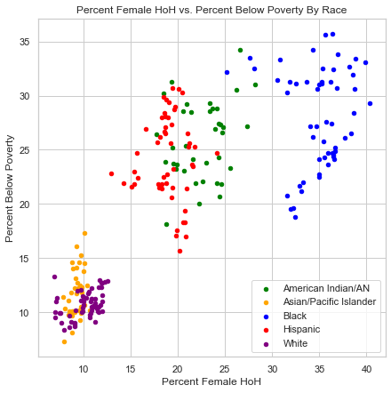

```python
groupedDF = finalDF.groupby(['Race'])
gf = finalDF.groupby(['Race'])
fig, ax = plt.subplots(figsize=(7, 7))
for key, group in gf :
    group.plot(ax = ax, kind='scatter', y='Percent Below Poverty', x='Percent Female HoH', label=key,color=colors[key])

plt.title('Percent Female HoH vs. Percent Below Poverty By Race')
plt.show()
```

There seems to be a linear relationship between these 2 variables. The more single parent households you see, th emore pverty is present. This graph also illustrates the racial divides of poverty with the black, Native American, and Hispanic populations seeing vastly higher rates of both single mother households and percent below poverty.

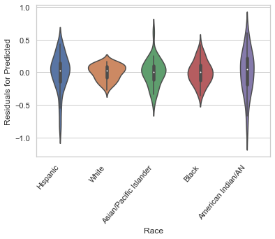

```python
finalDF["Residuals for Predicted"] = newRes.resid

sb.violinplot( data = finalDF, x= 'Race', y='Residuals for Predicted')
plt.xticks(rotation=50, ha='right')

plt.xlabel('Race')
plt.ylabel('Residuals for Predicted')
```

Although the length of the plots may suggest some level of variability, the relaitvely high concentration of data toards the median indicates our regression model was likely a good fit.

```
[Text(0.5, 1.0, 'Residuals for Predicted vs Fitted Values Model')]
```

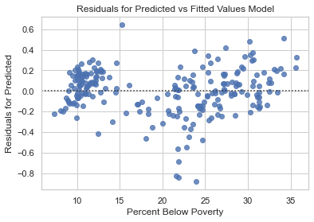

```python
sb.residplot(data=finalDF, x= "Percent Below Poverty",
             y="Residuals for Predicted").set(title="Residuals for Predicted vs Fitted Values Model")
```

The scatteredness of the final residual plot tells us that our model does illustrate a linear relationship between our predicted values for percent below poverty and actual percent below poverty, indicating that our predicted values we likely very accurate and generally mapped onto the reality of percentage below poverty among different the different racial groups.

# Table 6: Race and Hispanic Origin of People by Mean Income and Sex: 1947 to 2021

```python
data6 = pd.read_excel("p03.xlsx", header = 9 ) #several headers, first one starts on line 9
print(data6.dtypes)
data6.head()
```

```
Unnamed: 0            object
Unnamed: 1            object
Current\ndollars      object
2021\ndollars         object
Unnamed: 4            object
Current\ndollars.1    object
2021\ndollars.1       object
dtype: object
```

|  | Unnamed: 0 | Unnamed: 1 | Current\ndollars | 2021\ndollars | Unnamed: 4 | Current\ndollars.1 | 2021\ndollars.1 |
| --- | --- | --- | --- | --- | --- | --- | --- |
| 0 | 2021 | 118237 | 68592 | 68592 | 119263 | 45792 | 45792 |
| 1 | 2020 (41) | 117931 | 64929 | 67961 | 118426 | 43188 | 45204 |
| 2 | 2019 | 116561 | 65144 | 69037 | 118731 | 43315 | 45903 |
| 3 | 2018 | 115219 | 61180 | 66011 | 116920 | 39803 | 42946 |
| 4 | 2017 (40) | 114737 | 59735 | 66023 | 116468 | 38395 | 42437 |

```python
# We mainly want to work with Male and Female Income in 2021 dollars. We will also take not of the amount of income earners for each group.

data6 = data6.rename(columns={"Unnamed: 0": "Year", "2021\ndollars": "Male_Income", "2021\ndollars.1": "Female_Income", "Unnamed: 1": "Amount_With_Income"})
data6 = data6.loc[:, ["Year", "Male_Income", "Female_Income","Amount_With_Income"]]
data6.head()
```

|  | Year | Male_Income | Female_Income | Amount_With_Income |
| --- | --- | --- | --- | --- |
| 0 | 2021 | 68592 | 45792 | 118237 |
| 1 | 2020 (41) | 67961 | 45204 | 117931 |
| 2 | 2019 | 69037 | 45903 | 116561 |
| 3 | 2018 | 66011 | 42946 | 115219 |
| 4 | 2017 (40) | 66023 | 42437 | 114737 |

Concetrate on data for each race. Use melt to tidy up data.

```python
# Tidy data for White subgroup

dWhite = data6.iloc[81:161,:]
dWhite['Race'] = 'White'
dWhite= dWhite.dropna()

# Melt data to make Race and gender categorical variables. This will be useful for our linear regression models.
dWhite = pd.melt(dWhite, id_vars=["Year", "Race", "Amount_With_Income"], value_vars=["Male_Income", "Female_Income"], value_name="Income", var_name="Gender")

dWhite
```

|  | Year | Race | Amount_With_Income | Gender | Income |
| --- | --- | --- | --- | --- | --- |
| 0 | 2021 | White | 93506 | Male_Income | 71091 |
| 1 | 2020 (41) | White | 93391 | Male_Income | 70345 |
| 2 | 2019 | White | 92667 | Male_Income | 71630 |
| 3 | 2018 | White | 91817 | Male_Income | 68622 |
| 4 | 2017 (40) | White | 91559 | Male_Income | 68764 |
| ... | ... | ... | ... | ... | ... |
| 137 | 1957 | White | 47833 | Female_Income | 15123 |
| 138 | 1956 | White | 47038 | Female_Income | 15253 |
| 139 | 1955 | White | 46586 | Female_Income | 15038 |
| 140 | 1954 | White | 45019 | Female_Income | 14654 |
| 141 | 1953 | White | 44991 | Female_Income | 14722 |

142 rows × 5 columns

```python
# Tidy data for Black subgroup

dBlack = data6.iloc[251:331,:]
dBlack['Race'] = 'Black'
dBlack= dBlack.dropna()
dBlack = pd.melt(dBlack, id_vars=["Year", "Race", "Amount_With_Income"], value_vars=["Male_Income", "Female_Income"], value_name="Income", var_name="Gender")

dBlack
```

|  | Year | Race | Amount_With_Income | Gender | Income |
| --- | --- | --- | --- | --- | --- |
| 0 | 2021 | Black | 13631 | Male_Income | 47797 |
| 1 | 2020 (41) | Black | 13606 | Male_Income | 47498 |
| 2 | 2019 | Black | 13164 | Male_Income | 47799 |
| 3 | 2018 | Black | 12932 | Male_Income | 44612 |
| 4 | 2017 (40) | Black | 12876 | Male_Income | 44865 |
| ... | ... | ... | ... | ... | ... |
| 137 | 1957 | Black | 5044 | Female_Income | 9147 |
| 138 | 1956 | Black | 4978 | Female_Income | 9202 |
| 139 | 1955 | Black | 4860 | Female_Income | 8326 |
| 140 | 1954 | Black | 4693 | Female_Income | 8660 |
| 141 | 1953 | Black | 4676 | Female_Income | 9004 |

142 rows × 5 columns

```python
# Tidy data for Asian subgroup

dAsian = data6.iloc[361:401,:]
dAsian['Race'] = 'Asian'
dAsian= dAsian.dropna()
dAsian = pd.melt(dAsian, id_vars=["Year", "Race", "Amount_With_Income"], value_vars=["Male_Income", "Female_Income"], value_name="Income", var_name="Gender")

dAsian
```

|  | Year | Race | Amount_With_Income | Gender | Income |
| --- | --- | --- | --- | --- | --- |
| 0 | 2021 | Asian | 7255 | Male_Income | 85632 |
| 1 | 2020 (41) | Asian | 7013 | Male_Income | 84606 |
| 2 | 2019 | Asian | 7010 | Male_Income | 85167 |
| 3 | 2018 | Asian | 6847 | Male_Income | 81913 |
| 4 | 2017 (40) | Asian | 6771 | Male_Income | 79527 |
| ... | ... | ... | ... | ... | ... |
| 67 | 1992 (22) | Asian | 2558 | Female_Income | 32469 |
| 68 | 1991 | Asian | 2358 | Female_Income | 31101 |
| 69 | 1990 | Asian | 2235 | Female_Income | 31581 |
| 70 | 1989 | Asian | 2112 | Female_Income | 33295 |
| 71 | 1988 | Asian | 2123 | Female_Income | 30244 |

72 rows × 5 columns

```python
# Tidy data for Hispanic subgroup

dHispanic = data6.iloc[405:455,:]
dHispanic['Race'] = 'Hispanic'
dHispanic= dHispanic.dropna()
dHispanic = pd.melt(dHispanic, id_vars=["Year", "Race", "Amount_With_Income"], value_vars=["Male_Income", "Female_Income"], value_name="Income", var_name="Gender")

dHispanic
```

|  | Year | Race | Amount_With_Income | Gender | Income |
| --- | --- | --- | --- | --- | --- |
| 0 | 2021 | Hispanic | 20158 | Male_Income | 48461 |
| 1 | 2020 (41) | Hispanic | 19935 | Male_Income | 46415 |
| 2 | 2019 | Hispanic | 19352 | Male_Income | 46944 |
| 3 | 2018 | Hispanic | 18981 | Male_Income | 45613 |
| 4 | 2017 (40) | Hispanic | 18544 | Male_Income | 44573 |
| ... | ... | ... | ... | ... | ... |
| 95 | 1978 | Hispanic | 3447 | Female_Income | 18337 |
| 96 | 1977 | Hispanic | 3376 | Female_Income | 18329 |
| 97 | 1976 (17) | Hispanic | 3099 | Female_Income | 17753 |
| 98 | 1975 (16) | Hispanic | 2945 | Female_Income | 17438 |
| 99 | 1974 (16)(15) | Hispanic | 3052 | Female_Income | 17774 |

100 rows × 5 columns

Combine the data from each race into one dataframe

```python
# Concetnate dataframes of each raec into one big datagrame
incData = pd.concat([ dHispanic ,dWhite , dAsian , dBlack], ignore_index=True, axis=0)

# Fix Year column as many entries have extra information besides just the year.
incData["Year"] = [year[0:4] for year in incData["Year"].astype(str)]
incData["Year"] = incData["Year"].astype(int)
incData["Income"] = incData["Income"].astype(int)
incData
```

|  | Year | Race | Amount_With_Income | Gender | Income |
| --- | --- | --- | --- | --- | --- |
| 0 | 2021 | Hispanic | 20158 | Male_Income | 48461 |
| 1 | 2020 | Hispanic | 19935 | Male_Income | 46415 |
| 2 | 2019 | Hispanic | 19352 | Male_Income | 46944 |
| 3 | 2018 | Hispanic | 18981 | Male_Income | 45613 |
| 4 | 2017 | Hispanic | 18544 | Male_Income | 44573 |
| ... | ... | ... | ... | ... | ... |
| 451 | 1957 | Black | 5044 | Female_Income | 9147 |
| 452 | 1956 | Black | 4978 | Female_Income | 9202 |
| 453 | 1955 | Black | 4860 | Female_Income | 8326 |
| 454 | 1954 | Black | 4693 | Female_Income | 8660 |
| 455 | 1953 | Black | 4676 | Female_Income | 9004 |

456 rows × 5 columns

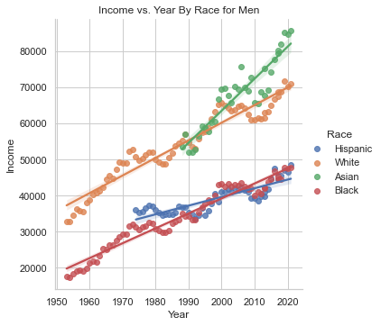

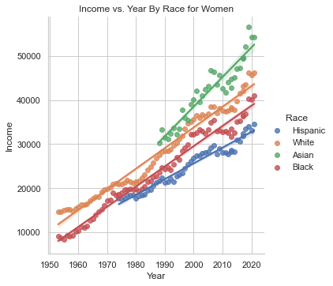

```python
# Color mappings for each race
colors = {"Hispanic" : "red", "Black" : "blue", "White": "purple" , "Asian" : "orange"}

# Specfically select for Male Income to plot
# Use Seaborn to make scatterplot
groupIncMen = incData.loc[incData["Gender"] == "Male_Income"]
sb.lmplot(x='Year', y='Income', data=groupIncMen, hue='Race', fit_reg=True, scatter=True).set(title='Income vs. Year By Race for Men')

# Specfically select for Female Income to plot
groupIncWomen = incData.loc[incData["Gender"] == "Female_Income"]
sb.lmplot(x='Year', y='Income', data=groupIncWomen, hue='Race', fit_reg=True, scatter=True).set(title='Income vs. Year By Race for Women')
```

There is something interesting to note about the data above. When accounting for gender, Black and hispanic men tend to do far worse than people of white or asian descent, however that distance is much narrower among women. This may suggest a shared experience between women that lead to them more often than not being treated more similarly across races compared to men. Women still maintain that Black and Hispanic people earn less and overall their earnings tend to be less then men, but that gap is a lot narrower than the one among men.

Why might this be?

```python
# Fitted Linear regression model for relationsip between Income and Race and Gender
incRes = smf.ols(formula='Income ~ Race * Gender', data=incData).fit()
print(incRes.summary())

incData["Residuals"] = incRes.resid
```

```
                            OLS Regression Results
==============================================================================
Dep. Variable:                 Income   R-squared:                       0.717
Model:                            OLS   Adj. R-squared:                  0.712
Method:                 Least Squares   F-statistic:                     162.0
Date:                Fri, 12 May 2023   Prob (F-statistic):          1.83e-118
Time:                        17:45:08   Log-Likelihood:                -4769.6
No. Observations:                 456   AIC:                             9555.
Df Residuals:                     448   BIC:                             9588.
Df Model:                           7
Covariance Type:            nonrobust
==========================================================================================================
                                             coef    std err          t      P>|t|      [0.025      0.975]
----------------------------------------------------------------------------------------------------------
Intercept                               4.191e+04   1419.175     29.532      0.000    3.91e+04    4.47e+04
Race[T.Black]                          -1.796e+04   1742.203    -10.311      0.000   -2.14e+04   -1.45e+04
Race[T.Hispanic]                       -1.692e+04   1861.231     -9.092      0.000   -2.06e+04   -1.33e+04
Race[T.White]                          -1.384e+04   1742.203     -7.944      0.000   -1.73e+04   -1.04e+04
Gender[T.Male_Income]                   2.611e+04   2007.017     13.009      0.000    2.22e+04    3.01e+04
Race[T.Black]:Gender[T.Male_Income]    -1.592e+04   2463.847     -6.462      0.000   -2.08e+04   -1.11e+04
Race[T.Hispanic]:Gender[T.Male_Income] -1.194e+04   2632.178     -4.536      0.000   -1.71e+04   -6765.303
Race[T.White]:Gender[T.Male_Income]       50.8568   2463.847      0.021      0.984   -4791.277    4892.990
==============================================================================
Omnibus:                       17.101   Durbin-Watson:                   0.209
Prob(Omnibus):                  0.000   Jarque-Bera (JB):                8.374
Skew:                          -0.086   Prob(JB):                       0.0152
Kurtosis:                       2.359   Cond. No.                         15.6
==============================================================================

Notes:
[1] Standard Errors assume that the covariance matrix of the errors is correctly specified.
```

```
[Text(0.5, 1.0, 'Income by Race for Men')]
```

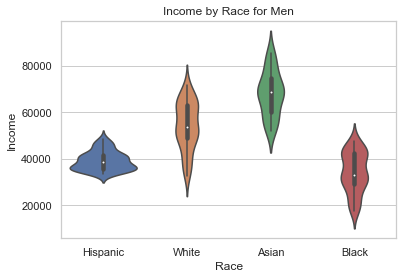

```python
sb.violinplot(data=groupIncMen, x="Race",
              y="Income").set(title="Income by Race for Men")
```

```
[Text(0.5, 1.0, 'Income by Race for Women')]
```

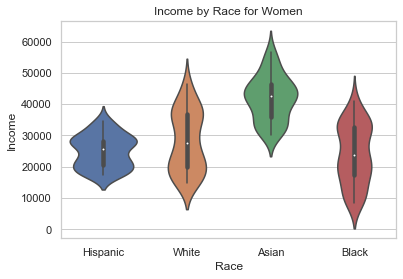

```python
sb.violinplot(data=groupIncWomen, x="Race",
              y="Income").set(title="Income by Race for Women")
```

Based off The last 2 violin plots, barring Hispanic, Men tend to have less concentration around the means across the races as apposed to women who's data is more conectrated around the median. This indicates a higher level of variation of income among men within their respective races as apposed to women.

So not only do men have more variation in income between races, but also within each race subset.

Some things to note:

- Asian women outperform Black men and slightly outperform Hispanic men
- White men out perform every single category except for Asian men

What may the socioeconomic factors be that lead to these outcomes of racial inequity?

A case study we can observe would be the black population in America. Historically, being brought over as slaves and enduring decases of Jim Crow, Black people would not be given the opportunity to build wealth. On top of that, discriminatory housing practices such as the redlining that came about from the New Deal efforts would overall inhibit the population's progress in increasing wealth. Because of this, we see higher rates of poverty among this population which in many cases leads to many kids not going through with higher education as it would either be too expensive or would not immedately bring in money needed to pay off bills and make ends meet. Historical factors such explain why there exists such racial inequity in America. [Source](https://news.harvard.edu/gazette/story/2021/06/racial-wealth-gap-may-be-a-key-to-other-inequities/)

In the case of Asian success, it is a little more complicated than what our data might lead one to believe. One factos to their success in America can be attributed to the fact many Asians are first or second generation immigrants. Immigrants more often than not have already attained higher education or have been well educated in some sort of trade ([Source](https://www.brookings.edu/research/asian-american-success-and-the-pitfalls-of-generalization/)). In addition, it is important to note "Asian" is an incredibly broad category. When we refer to the fact that Asian women outperform Black and hispanic men, much of this data influenced by the subsets of the Asian population that tend to earn more. Groups such as Indian, Taiwanese, Chinese, and Malaysian, tend to outperform many of their other ethnicitites such as Japanese, Bangladeshi, Thai, Vietnamese, etc. Many of which make up a much smaller population than the aforemention top earners.

It's important to understand historical context behind the inequities between races in order to prevent biased reasoning to explain the differences.

**Residuals:** The following violin plot is a plot of the residuals measured previously from the linear regression analysis of income by Race interacting with Gender.

```
[Text(0.5, 1.0, 'Residuals by Race')]
```

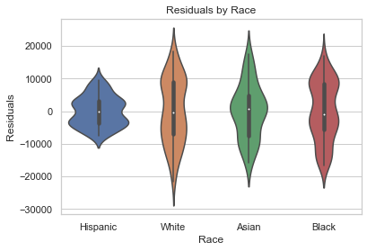

```python
sb.violinplot(data=incData, x="Race", y="Residuals").set(title="Residuals by Race")
```

The residual plot above illustrates that median values are all concentrated around 0 indicating that the aforementioned fitted linear regression is a good fit, however, due to the length of some of the plots, this indicates a signficant amount variation. Thus we can't in good faith say the model is best fit, so we need to work to alleviate this.

```python
# Obtain mean income and the Income's standard deviation
mean = incData["Income"].mean()
std = incData["Income"].std()

# Standardize Income = (subtract each income value by the mean) / standard deviation
incData["Income_std"] = (incData["Income"] - mean) / std

# Select the training to data to be 95% of the data
inc_train = incData.sample(frac=0.95)
inc_test = incData.drop(inc_train.index)

# Fit the regression model to see the relationship between standardized income and race and gender
inc_model = smf.ols(formula="Income_std ~ Race + Gender ",data=inc_test).fit()

# Print fitted regression model summary
print(inc_model.summary())
```

```
                            OLS Regression Results
==============================================================================
Dep. Variable:             Income_std   R-squared:                       0.631
Model:                            OLS   Adj. R-squared:                  0.549
Method:                 Least Squares   F-statistic:                     7.693
Date:                Fri, 12 May 2023   Prob (F-statistic):           0.000849
Time:                        17:45:09   Log-Likelihood:                -19.275
No. Observations:                  23   AIC:                             48.55
Df Residuals:                      18   BIC:                             54.23
Df Model:                           4
Covariance Type:            nonrobust
=========================================================================================
                            coef    std err          t      P>|t|      [0.025      0.975]
-----------------------------------------------------------------------------------------
Intercept                 0.4806      0.632      0.760      0.457      -0.848       1.809
Race[T.Black]            -1.4631      0.685     -2.136      0.047      -2.902      -0.024
Race[T.Hispanic]         -1.3396      0.702     -1.910      0.072      -2.813       0.134
Race[T.White]            -0.3792      0.692     -0.548      0.590      -1.832       1.074
Gender[T.Male_Income]     0.8930      0.277      3.220      0.005       0.310       1.476
==============================================================================
Omnibus:                        2.129   Durbin-Watson:                   1.730
Prob(Omnibus):                  0.345   Jarque-Bera (JB):                1.665
Skew:                          -0.640   Prob(JB):                        0.435
Kurtosis:                       2.686   Cond. No.                         12.7
==============================================================================

Notes:
[1] Standard Errors assume that the covariance matrix of the errors is correctly specified.
```

#### Poverty, Race, and Location

Here, we're going to use table to plot Income vs Race using the same functions as before.

At this point we've shown that Poverty varies by race and that a possible contributor is income. Now lets see the role that geography maybe.

We'll now use to Table 4 to make a plot that represents Percent in Poverty vs State.

The current layout of table 4 makes this complicated, however.

```python
povByRace.head(5)
```

|  | Location | White | Black | Hispanic | Asian/Native Hawaiian and Pacific Islander | American Indian/Alaska Native | Multiple Races | Total |
| --- | --- | --- | --- | --- | --- | --- | --- | --- |
| 0 | United States | 0.095 | 0.217 | 0.176 | 0.102 | 0.259 | 0.141 | 0.128 |
| 1 | Alabama | 0.119 | 0.247 | 0.244 | 0.114 | 0.144 | 0.184 | 0.160 |
| 2 | Alaska | 0.078 | 0.251 | 0.130 | NaN | 0.206 | 0.124 | 0.110 |
| 3 | Arizona | 0.089 | 0.168 | 0.171 | 0.111 | 0.348 | 0.105 | 0.129 |
| 4 | Arkansas | 0.137 | 0.272 | 0.218 | 0.116 | 0.117 | 0.157 | 0.164 |

We're going to use pandas melt() to turn the 7 race columns to 1 column so that we can plot all the races and group by color. Additionally, this will allow us to use dropna() when there's nan values.

Here's the information on how to use pandas melt: https://pandas.pydata.org/docs/reference/api/pandas.melt.html.

Here's a helpful example as the documentation is unclear: https://www.geeksforgeeks.org/python-pandas-melt/

|  | Location | Race | Percent in Poverty |
| --- | --- | --- | --- |
| 0 | United States | White | 0.094971 |
| 1 | Alabama | White | 0.119019 |
| 2 | Alaska | White | 0.078003 |
| 3 | Arizona | White | 0.088989 |
| 4 | Arkansas | White | 0.136963 |
| 5 | California | White | 0.090027 |
| 6 | Colorado | White | 0.077026 |
| 7 | Connecticut | White | 0.067993 |
| 8 | Delaware | White | 0.072998 |
| 9 | District of Columbia | White | 0.049988 |

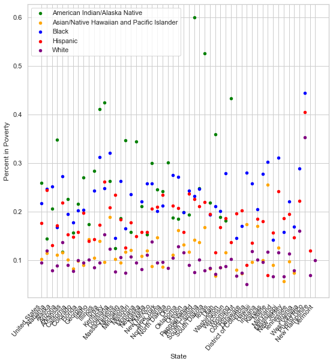

```python
# color coding races
colors = {"American Indian/Alaska Native" : "green", "Hispanic" : "red", "Black" : "blue", "White": "purple" ,
          'Asian/Native Hawaiian and Pacific Islander': "orange"}
#choosing which new columns to make and which old columns to make the values of the new column
meltedPovByRace = pd.melt(povByRace, id_vars = ['Location'] , value_vars = ['White','Black','Hispanic', 'White',
                                                                           'Asian/Native Hawaiian and Pacific Islander',
                                                                           'American Indian/Alaska Native'],
                          var_name= ['Race'], value_name= 'Percent in Poverty')
# Note: we dont need the last 2 columns
meltedPovByRace = meltedPovByRace.dropna()
meltedPovByRace['Percent in Poverty'] = meltedPovByRace['Percent in Poverty'].astype(np.float16) #necessary for scatter plot to work

#using same graphing process as below
fig, ax = plt.subplots(figsize=(9, 9))
groupedByRace = meltedPovByRace.groupby(['Race'])
for key, group in groupedByRace :
    group.plot(ax=ax, kind='scatter', y='Percent in Poverty', x='Location', label=key,color=colors[key])

plt.xticks(rotation=50, ha='right')
plt.xlabel('State')
plt.ylabel('Percent in Poverty')

meltedPovByRace.head(10)
```

If state did not have an affect on poverty, the scatter plots would be a in a straight line throughout the x-axis, but that is not the case. The fluctuations indicate that there is indeed an effect of state on poverty rates. In other words, poverty varies by race and this variations varies by state.

To confirm this theory, lets perform a linear regression.

```python
res4= smf.ols(formula= "Q(\"Percent in Poverty\") ~  Race + Location", data=meltedPovByRace).fit()
print(res4.summary())
```

```
                               OLS Regression Results
===================================================================================
Dep. Variable:     Q("Percent in Poverty")   R-squared:                       0.711
Model:                                 OLS   Adj. R-squared:                  0.618
Method:                      Least Squares   F-statistic:                     7.685
Date:                     Fri, 12 May 2023   Prob (F-statistic):           9.95e-26
Time:                             17:45:11   Log-Likelihood:                 381.69
No. Observations:                      232   AIC:                            -649.4
Df Residuals:                          175   BIC:                            -452.9
Df Model:                               56
Covariance Type:                 nonrobust
======================================================================================================================
                                                         coef    std err          t      P>|t|      [0.025      0.975]
----------------------------------------------------------------------------------------------------------------------
Intercept                                              0.2551      0.025     10.067      0.000       0.205       0.305
Race[T.Asian/Native Hawaiian and Pacific Islander]    -0.1412      0.012    -11.508      0.000      -0.165      -0.117
Race[T.Black]                                         -0.0272      0.012     -2.216      0.028      -0.051      -0.003
Race[T.Hispanic]                                      -0.0784      0.012     -6.577      0.000      -0.102      -0.055
Race[T.White]                                         -0.1607      0.012    -13.583      0.000      -0.184      -0.137
Location[T.Alaska]                                    -0.0223      0.036     -0.617      0.538      -0.094       0.049
Location[T.Arizona]                                    0.0038      0.034      0.111      0.912      -0.063       0.071
Location[T.Arkansas]                                  -0.0016      0.034     -0.047      0.962      -0.069       0.065
Location[T.California]                                -0.0212      0.034     -0.624      0.533      -0.088       0.046
Location[T.Colorado]                                  -0.0456      0.034     -1.342      0.181      -0.113       0.021
Location[T.Connecticut]                               -0.0310      0.036     -0.857      0.393      -0.102       0.040
Location[T.Delaware]                                  -0.0240      0.036     -0.663      0.508      -0.095       0.047
Location[T.District of Columbia]                      -0.0047      0.036     -0.131      0.896      -0.076       0.067
Location[T.Florida]                                   -0.0192      0.034     -0.565      0.573      -0.086       0.048
Location[T.Georgia]                                   -0.0026      0.034     -0.076      0.939      -0.070       0.065
Location[T.Hawaii]                                    -0.0017      0.036     -0.047      0.962      -0.073       0.070
Location[T.Idaho]                                     -0.0210      0.036     -0.583      0.561      -0.092       0.050
Location[T.Illinois]                                  -0.0018      0.034     -0.053      0.957      -0.069       0.065
Location[T.Indiana]                                    0.0118      0.036      0.327      0.744      -0.059       0.083
Location[T.Iowa]                                       0.0520      0.034      1.529      0.128      -0.015       0.119
Location[T.Kansas]                                     0.0098      0.036      0.272      0.786      -0.061       0.081
Location[T.Kentucky]                                   0.0628      0.034      1.847      0.066      -0.004       0.130
Location[T.Louisiana]                                  0.0468      0.034      1.376      0.171      -0.020       0.114
Location[T.Maine]                                      0.0325      0.036      0.899      0.370      -0.039       0.104
Location[T.Maryland]                                  -0.0400      0.036     -1.107      0.270      -0.111       0.031
Location[T.Massachusetts]                             -0.0374      0.034     -1.100      0.273      -0.105       0.030
```

[output cut: 25 more lines]

```
Location[T.Vermont]                                    0.0056      0.059      0.094      0.925      -0.111       0.123
Location[T.Virginia]                                  -0.0360      0.036     -0.997      0.320      -0.107       0.035
Location[T.Washington]                                -0.0282      0.034     -0.829      0.408      -0.095       0.039
Location[T.West Virginia]                              0.0570      0.039      1.449      0.149      -0.021       0.135
Location[T.Wisconsin]                                 -0.0042      0.034     -0.123      0.902      -0.071       0.063
Location[T.Wyoming]                                    0.0486      0.039      1.234      0.219      -0.029       0.126
==============================================================================
Omnibus:                       55.729   Durbin-Watson:                   2.218
Prob(Omnibus):                  0.000   Jarque-Bera (JB):              276.201
Skew:                           0.824   Prob(JB):                     1.06e-60
Kurtosis:                       8.085   Cond. No.                         55.0
==============================================================================

Notes:
[1] Standard Errors assume that the covariance matrix of the errors is correctly specified.
```

#### Income and Race

We've shown that there's a discrepincy in poverty rates between races, so now lets try to see why.

One guess we have is possible variations in income.

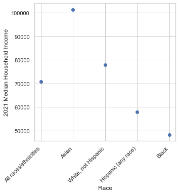

```python
colors = {"American Indian/AN" : "green", "Hispanic" : "red", "Black" : "blue", "White": "purple" ,
          "Asian/Pacific Islander" : "orange"}

fig, ax = plt.subplots(figsize=(5, 5))
plt.scatter(y= df['2021 Median Household Income'], x=df['Race/Ethnicity of Household Head'])

plt.xticks(rotation=45, ha='right')
plt.xlabel('Race')
plt.ylabel('2021 Median Household Income')
plt.show()
```

The results in this plot do show fluctuations in income by race as the average changes drastically with each race. We wont get too deep into this trend other than showing that it exists.

## Analysis, Hypothesis Testing, and Machine Learning

The following will be a process we have seen previously. We will show a fitted linear regression model of the standardized data for percent in poverty. Following that we will use the standardized data to make a gradient descent model.

```python
# Obtain mean Percent in Poverty and the Percent in Poverty's standard deviation
m = meltedPovByRace["Percent in Poverty"].mean()
s = meltedPovByRace["Percent in Poverty"].std()

# Standardize Percent in Poverty = (subtract each Percent in Poverty by the mean) / standard deviation
meltedPovByRace["Percent_in_Poverty_std"] = (meltedPovByRace["Percent in Poverty"] - m) / s

# Select the training to data to be 95% of the data
pov_train = meltedPovByRace.sample(frac=0.95)
pov_test = meltedPovByRace.drop(pov_train.index)

# Melt data to properly make Location a cateogry that can act as an interaction term
pov_test = pov_test.melt( id_vars=["Race", "Percent in Poverty", "Percent_in_Poverty_std"], value_vars=["Location"], var_name="Location")
pov_test["Location"] = pov_test["Location"].astype(str)

# Fit the regression model to see the relationship between standardized Percent in Poverty and race and location
pov_model = smf.ols(formula="Percent_in_Poverty_std ~ Race : Location",data=pov_test).fit()

# Print fitted regression model summary
print(pov_model.summary())
```

```
                              OLS Regression Results
==================================================================================
Dep. Variable:     Percent_in_Poverty_std   R-squared:                       0.802
Model:                                OLS   Adj. R-squared:                  0.689
Method:                     Least Squares   F-statistic:                     7.093
Date:                    Fri, 12 May 2023   Prob (F-statistic):             0.0131
Time:                            17:45:12   Log-Likelihood:                -7.7990
No. Observations:                      12   AIC:                             25.60
Df Residuals:                           7   BIC:                             28.02
Df Model:                               4
Covariance Type:                nonrobust
=========================================================================================================================================
                                                                            coef    std err          t      P>|t|      [0.025      0.975]
-----------------------------------------------------------------------------------------------------------------------------------------
Intercept                                                                 1.2544      0.429      2.923      0.022       0.240       2.269
Race[T.Asian/Native Hawaiian and Pacific Islander]:Location[Location]    -2.2583      0.743     -3.039      0.019      -4.016      -0.501
Race[T.Black]:Location[Location]                                          0.0232      0.607      0.038      0.971      -1.412       1.458
Race[T.Hispanic]:Location[Location]                                      -1.0659      0.526     -2.028      0.082      -2.309       0.177
Race[T.White]:Location[Location]                                         -2.2773      0.554     -4.111      0.005      -3.587      -0.967
==============================================================================
Omnibus:                        0.032   Durbin-Watson:                   2.468
Prob(Omnibus):                  0.984   Jarque-Bera (JB):                0.120
Skew:                           0.015   Prob(JB):                        0.942
Kurtosis:                       2.511   Cond. No.                         6.59
==============================================================================

Notes:
[1] Standard Errors assume that the covariance matrix of the errors is correctly specified.
```

**Gradient Descent**

```python
# First we need our independendent and dependednt variables

# Dependendent
y = pov_test["Percent_in_Poverty_std"].to_numpy()

# Independent
X = sm.add_constant(pov_test[['Percent in Poverty']].to_numpy())

# Gradient descent algorithm
gradientReg = slm.SGDRegressor(eta0=0.00001).fit(X,y)

# Obtain the coefficents
theta = gradientReg.coef_
```

```python
# Make a datagrame that takes our previous test results
final_pov = pov_test[['Race','Location', 'Percent_in_Poverty_std', 'Percent in Poverty']].copy().reset_index(drop=True)

# Add our gradient predictions by applying the coeefecints to a doproduct against the values from the
# Indepdnednt values and "un"-standardize the values
final_pov['Gradient Prediction'] = (pd.Series([theta.dot(row) for row in X]) * s) + m

# To see how much the was off by actual percentage in poverty
final_pov['Gradient Miss'] = abs(final_pov['Gradient Prediction'] - pov_test['Percent in Poverty'])

# Print out final table
final_pov
```

|  | Race | Location | Percent_in_Poverty_std | Percent in Poverty | Gradient Prediction | Gradient Miss |
| --- | --- | --- | --- | --- | --- | --- |
| 0 | White | Location | -0.900391 | 0.094971 | 0.173344 | 0.078373 |
| 1 | White | Location | -0.969238 | 0.088989 | 0.173344 | 0.084355 |
| 2 | White | Location | -1.199219 | 0.068970 | 0.173344 | 0.104374 |
| 3 | Black | Location | 1.582031 | 0.311035 | 0.173345 | 0.137690 |
| 4 | Black | Location | 0.973145 | 0.258057 | 0.173345 | 0.084712 |
| 5 | Hispanic | Location | -0.199219 | 0.156006 | 0.173344 | 0.017338 |
| 6 | Hispanic | Location | 0.731934 | 0.237061 | 0.173345 | 0.063716 |
| 7 | Hispanic | Location | 0.524414 | 0.218994 | 0.173345 | 0.045650 |
| 8 | Hispanic | Location | -0.302979 | 0.146973 | 0.173344 | 0.026372 |
| 9 | Asian/Native Hawaiian and Pacific Islander | Location | -1.003906 | 0.085999 | 0.173344 | 0.087346 |
| 10 | American Indian/Alaska Native | Location | 0.375977 | 0.206055 | 0.173345 | 0.032710 |
| 11 | American Indian/Alaska Native | Location | 2.132812 | 0.358887 | 0.173345 | 0.185542 |

```python
print("Gradient miss: ", final_pov['Gradient Miss'].mean())
```

```
Gradient miss:  0.0790148268811729
```

# Insight and Policy

The totality of the analysis in this tutorial has revealed significant themes in the existence of poverty in America. Through the collection, cleaning, processing, and analysis of each our tables we've been able to witness trends of poverty in America across time, race, and state that have allowed us to make generalizations about our society as a whole.

Our analysis of poverty in America across time has shown that time alone is not an entirely accurate predictor of poverty. In general, poverty has decreased in the last few decades, however, the uncertainty and unpredictability of the world leaves us unable to guarantee how poverty will look in the next decade just by looking at the year. Any event can cause a drop and uproar in poverty rates.

Our analysis of poverty by race shows that certain races are susceptible to higher poverty rates than others. Across the board, the White group consistently expereinced lower rates of poverty than the others, specifically, Black, Hispanic, or American Indian groups.

Finally, we've noticed that a trend in pay discrepncies across races that matched the trend in poverty across races.

So in sum, we can say the following:

- Black, American Indian, and Hispanic groups experience higher rates of poverty than White and Asian groups.
- Black, American Indian, and Hispanic groups experience higher rates of poverty in certain states.
- Black, American Indian, and Hispanic groups in average recieve lower incomes across the country than their White and Asian counterparts.
- Poverty across time is inconsistent, but all races experiences similiar fluctuations across time.

Now that we know these discrepenscies exist, it's our responsibility to take measures to diminish the role race has in poverty. It's our job as members of society to ensure all races have equal access to education, jobs, and wealth accumulation.

Some ways we can go about implmenting equity, welfare and bring people of color out of poverty are:

- Invest heavily in children
  - Studies show that the rate of return on investment on a person's life is high at a younger ange than when they are older. They become much more likely to perform well in school and complete their education. These tend to be indicators that one's future won't be filled with poverty (Source).
- Closing the gender pay gap
  - Many poverty striken households are led by single mothers. Despite this, not only do they have to work to feed their children, they get payed less on average than a man would. There are many ways to go about closing the pay gap.
    - One way to lessen the gap would be to make paid maternal and paternal leave mandatory. Many companies will try to make sure they pay as little as possible for PTO, and parental leave tends to be quite a while. In many cases, this would lessen the chance of a woman attaing a certain position in the company due to the expectation of maternal leave. So making it an expecetation that men would also see time off as well would help alleviate this issue.
  - Early investment in education for girls would also allow them to thrive in the future. We have seen as time has passed more an more women attaining higher education and their wages have reflected this. ([Source](https://skills4training.org/how-to-overcome-the-gender-pay-gap/))
- Minimum Wage
  - The American economy makes it difficult for people to argue for higher wages at times, so a means of alleviating this would be to increase the minimum wage to a more livable standard.
  - $15/hr is something that has been floating around for a while. In general the goal would be that you would be able to not only live off your income, but have extra that can be used for other purposes.

Overall, we hope this analysis is able to show the current state of affairs in terms of Poverty in America and how race plays a major role in it. Racial issues often intersect with other social issues like gender inequality, geographic differences, immigration problems and so forth. We've introduced some means of alleviating these problems and hope there is a strong enough political will to back these efforts.

## Sources

1. Britannica, T. Editors of Encyclopaedia (2023, April 6). poverty. Encyclopedia Britannica. https://www.britannica.com/topic/poverty
2. https://www.worldvision.ca/stories/child-sponsorship/what-is-poverty
3. https://www.cnbc.com/2023/03/07/why-poverty-might-be-far-worse-in-the-us-than-its-reported.html#:~:text=As%20of%20January%202021%2C%2037.9,the%20United%20States%20Census%20Bureau
4. https://pandas.pydata.org/pandas-docs/stable/user_guide/10min.html
5. https://pandas.pydata.org/docs/reference/api/pandas.read_csv.html
6. https://pandas.pydata.org/docs/reference/api/pandas.read_excel.html
7. https://www.geeksforgeeks.org/implementing-web-scraping-python-beautiful-soup/
8. https://www.w3schools.com/python/ref_requests_get.asp
9. https://matplotlib.org/stable/api/_as_gen/matplotlib.pyplot.plot.html
10. https://en.wikipedia.org/wiki/Standard_score
11. https://www.americanprogress.org/article/women-of-color-and-the-wage-gap/
12. https://www.brookings.edu/research/asian-american-success-and-the-pitfalls-of-generalization/
13. https://news.harvard.edu/gazette/story/2021/06/racial-wealth-gap-may-be-a-key-to-other-inequities/
14. https://reader.elsevier.com/reader/sd/pii/S1574069206010129?token=765AF0CCE8FAB996755A224F861B6DC82CFD5233BFFB9F8FC958C9D818530B6763583B5FA59AEB60175BF5F0815F070B&originRegion=us-east-1&originCreation=20230512065149
15. https://skills4training.org/how-to-overcome-the-gender-pay-gap/
16. https://www.geeksforgeeks.org/python-pandas-melt/
17. https://pandas.pydata.org/docs/reference/api/pandas.melt.html
18. https://www.ibm.com/topics/gradient-descent#:~:text=Gradient%20descent%20is%20an%20optimization,each%20iteration%20of%20parameter%20updates